# **Web Scraping con R y RStudio**

Sesión 1:** Introducción al raspado web con R y RStudio

Agustín Nieto** @agusnieto77

30/11/2022

# **Descripción del curso**

El presente curso tiene como principal objetivo entregar una aproximación general a técnicas avanzadas de web scraping que facilita el lenguaje de programación R. A lo largo de los encuentros se abordarán los diferentes tópicos referidos a las distintas etapas del raspado de páginas de internet (detención del tipo de página a raspar, inspección de su estructura básica, detección de los tags que enmarcan la información de interés, desarrollo de funciones para encadenar las líneas de código necesarias para obtener la información, transformación de datos semiestructurado a datos estructurados en formato ‘tidy’). Estos pasos quedarán escritos en scripts enmarcados en un proyecto de Rstudio.

Durante el curso se compartirán (vía GitHub) archivos de datos, código, aplicaciones y referencias bibliográficas de interés. De este modo, cada estudiante contará con el material ya construido en base al cual podrá continuar su aprendizaje a la vez que podrá implementar rápidamente el uso de técnicas avanzadas de web scraping en R y RStudio para sus propios fines de investigación, sea en el área académica o profesional.

## **¿Qué es Git?**

Es un **Sistema de Control de Versiones Distribuido** (DVCS) que se utiliza para guardar diferentes versiones de archivos y poder recuperarlos luego.

Facilita el registro y comparación de diferentes versiones de un archivo. Esto significa que los detalles sobre **qué** cambió, **quién**, **cuándo** lo cambió, se pueden revisar.

**En resumen**: Git es un software de DVCS local que permite a lxs desarrolladorxs guardar instantáneas de sus proyectos a lo largo del tiempo.

*Git* es **distinto** a *GitHub*

> **[Más info sobre Git](https://es.wikipedia.org/wiki/Git)**

## **¿Qué es GitHub?**

A diferencia de Git, **GitHub** es una plataforma basada en la web que incorpora las características de control de versiones de Git para que puedan ser utilizadas de forma colaborativa. Es una *interfaz web* entre Git y lxs usuarixs que incluye características de gestión de proyectos y equipos, así como oportunidades para la creación de redes y la codificación social.

**Git** y **GitHub** son dos entidades diferentes que te ayudan a gestionar y alojar archivos. En otras palabras Git sirve para controlar las versiones de los archivos mientras que GitHub es una plataforma para alojar repositorios Git.

> **[Más info sobre Git](https://es.wikipedia.org/wiki/GitHub)**

# **Objetivos de aprendizaje**

## **Objetivo general**

Aproximar a lxs estudiantes a diferentes técnicas de web scraping, al conocimiento de las estructuras de las páginas web y sus etiquetas html, a la transformación de datos semiestructurado a datos estructurado, a la gestión de corpus de texto, en base a las distintas librerías disponibles en CRAN. Se espera que al final del curso cada estudiante haya integrado los conocimientos necesarios y suficientes para adaptar autónomamente las distintas funciones de raspado web desarrolladas en el marco del curso a sus propias instancias de investigación académica y/o profesional.

## **Objetivos específicos**

- Identificar las distintas estructuras que presentan las páginas web para definir el enfoque a ser aplicado en el proceso de raspado web.
- Manejar las herramientas básicas para desarrollar una inspección profunda de la estructura de etiquetas html de distintas páginas web.
- Conocer el abanico de librerías y paquetes de funciones disponible en CRAN para desarrollar raspado web con R y Rstudio.
- Desarrollar funciones de raspado web con el enfoque adecuado según sea el contenido y la estructura de la página web.
- Poder almacenar las grandes masas de texto raspadas en la web en un formato tabular.
- Reconocer la bibliografía especializada sobre las técnicas de web scraping.

# **Contenido de la presente sesión**

- Presentación general del curso.
- Un repaso sobre el lenguaje de programación R y de RStudio.
- Organización del directorio de trabajo. Creación de proyectos.
- Vinculación con GitHub.
- ¿Qué es el web scraping?
- ¿Cuándo debemos hacer uso del web scraping y cuando no?
- Algunos ejemplos de uso de APIs: Twitter y el paquete rtweet.

## **R y RStudio**

**R** es un **entorno** y **lenguaje de programación** de código abierto que proporciona una variedad de técnicas estadísticas y gráficas. Es un proyecto GNU (General Public License), cualquier persona puede estudiar, usar, modificar y compartir el software sin que pertenezca a nadie.

**RStudio** es un **Entorno de Desarrollo Integrado** (IDE) para el lenguaje de programación **R** (y otros como Python), dedicado a la computación estadística y gráficos. Incluye una consola, editor de sintaxis que apoya la ejecución de código, así como herramientas para el trazado, la depuración y la gestión del espacio de trabajo.

> **[Ir al colab](https://drive.google.com/file/d/1u5ZMbNZ3nl9NoZ4yIdXG4x6VSOgky006/view?usp=sharing)**

## **¿Qué es el web scraping?**

Se denomina **web scraping** (en inglés = arañado o raspado web) a la extracción (automatizada y dirigida) y almacenamiento computacional del contenido de páginas web. La información raspada puede ser de diverso tipo. Por ejemplo, contactos telefónicos, correo electrónico, direcciones físicas, información censal, notas periodísticas o de opinión, comentarios de lectorxs, precios, etc. Esta información se almacena en formatos diversos: vectores lógicos, numéricos o de texto plano, marcos de datos, tablas, listas, matrices, arrays. Los objetos de clase arrays son poco usuales. En este curso nos vamos a centrar en los objetos de tipo tabular (tibbles y data frames). También usaremos objetos de clase lista y vector. En términos generales, el web scraping toma información web semi-estructurada y la devuelve en un formato estructurado. Como dijimos, aquí usaremos el formato tibble.

## **¿Cuándo debemos hacer uso del web scraping y cuando no?**

- Cuando no hay un conjunto de datos disponible para la problemática que queremos abordar.
- Cuando no hay una API (interfaz de programación de aplicaciones) pública disponible que permita un intercambio fluido con los datos que necesitamos recopilar.

## **Twitter y el paquete {rtweet}**

```r
library(rtweet)

rstats <- search_tweets(q = "#RStats", n = 2000, include_rts  = FALSE)

rstats |> head()
```

```
## # A tibble: 6 × 43
##   created_at               id id_str        full_…¹ trunc…² displ…³ entities
##   <dttm>                <dbl> <chr>         <chr>   <lgl>     <dbl> <list>
## 1 2022-11-28 19:23:22 1.60e18 159735549586… "If yo… FALSE       103 <named list>
## 2 2022-11-29 18:32:55 1.60e18 159770518763… "Pract… FALSE       249 <named list>
## 3 2022-11-30 09:19:57 1.60e18 159792841593… "Incre… FALSE       279 <named list>
## 4 2022-11-30 15:08:39 1.60e18 159801617091… "still… FALSE       280 <named list>
## 5 2022-11-30 15:05:02 1.60e18 159801525989… "\U000… FALSE       273 <named list>
## 6 2022-11-30 15:02:09 1.60e18 159801453500… "CRAN … FALSE        27 <named list>
## # … with 36 more variables: metadata <list>, source <chr>,
## #   in_reply_to_status_id <dbl>, in_reply_to_status_id_str <chr>,
## #   in_reply_to_user_id <dbl>, in_reply_to_user_id_str <chr>,
## #   in_reply_to_screen_name <chr>, geo <list>, coordinates <list>,
## #   place <list>, contributors <lgl>, is_quote_status <lgl>,
## #   quoted_status_id <dbl>, quoted_status_id_str <chr>, quoted_status <list>,
## #   retweet_count <int>, favorite_count <int>, favorited <lgl>, …
```

## **Plot con {rtweet}**

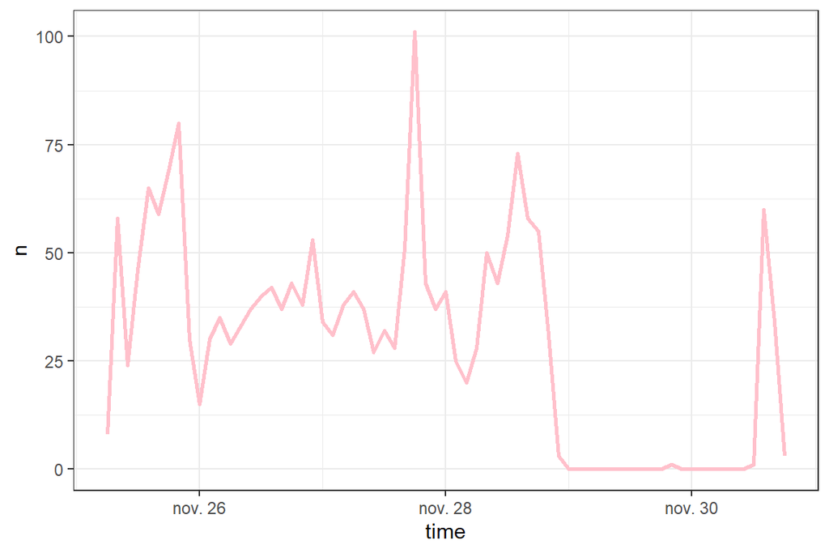

```r
rtweet::ts_plot(rstats, by = "2 hours", size = 0.9, color = 'pink') +
  ggplot2::theme_bw()
```